# R Notebook

```r
#install.packages("MPsychoR")
library("MPsychoR")
library("qgraph")
library(dplyr)
```

[output not shown]

# Force-directed plotting with Fruchterman–Reingold

Most studies on networks in psychopathology have used the Fruchterman-Reingold (FR) algorithm to create graphs. This algorithm, similar to methods by Kamada and Kawai, is like setting up a system of balls connected by stretchy strings. The strings pull connected balls closer, while the other balls push them apart, resulting in a neat graph where nodes are well-spaced and edges are evenly distributed.

Force-directed algorithms aim to produce visually pleasing graphs by minimizing edge crossings and spacing nodes evenly. The goal is not to place the nodes in specific meaningful locations, but to make the network easy to view, showing connections and clusters clearly.

It’s important to avoid interpreting the spatial positions of nodes in these graphs, as the placement is not meant to convey specific meanings. Misinterpreting the layout is a common mistake, as it’s natural to want to find meaning in the arrangement.

The FR algorithm is the default in the qgraph R package, making it straightforward to use. We will illustrate this with a zero-order correlation network of adults with OCD and depression.

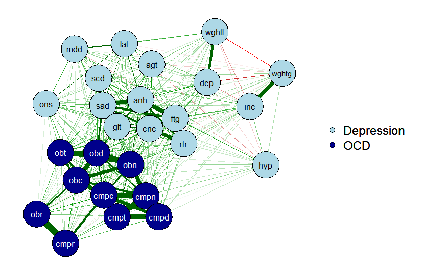

```r
zeroorder <- cor(Rogers)

qgraph(zeroorder, layout = "spring", groups = list(Depression = 1:16, OCD = 17:26), color = c("lightblue", "darkblue"))
```

```r
df <- read.csv("df_gb.csv")
df <- df[2:15]
head(df)
```

```r
df_t <- df %>%
  mutate(fltsd = ifelse(fltsd > 4, NA, fltsd))  %>%
  mutate(fltdpr = ifelse(fltdpr > 4, NA, fltdpr))  %>%
  mutate(cldgng = ifelse(cldgng > 4, NA, cldgng))  %>%
  mutate(slprl = ifelse(slprl > 4, NA, slprl))  %>%
  mutate(cgtsmok = ifelse(cgtsmok > 7, NA, cgtsmok))  %>%
  mutate(alcfreq = ifelse(alcfreq > 7, NA, alcfreq))  %>%
  mutate(dosprt = ifelse(dosprt > 7, NA, dosprt))  %>%
  mutate(ctrlife = ifelse(ctrlife > 10, NA, ctrlife)) %>%
  mutate(cgtsmok = recode(cgtsmok, `7` = 1, `6` = 2, `5` = 3, `4`= 4, `1` = 7, `2` = 6, `3` = 5)) %>%
  mutate(alcfreq = recode(alcfreq, `7` = 1, `6` = 2, `5` = 3, `4`= 4, `1` = 7, `2` = 6, `3` = 5))
```

```r
df_t <- df_t %>%
  rename(
    control_over_life = ctrlife,
    #everything_effort = flteeff,
    restless_sleep = slprl,
    gender = gndr,
    unable_med_consultation_12_months = medtrun,
    felt_depressed = fltdpr,
    could_not_get_going = cldgng,
    felt_sad = fltsd,
    household_income = hinctnta,
    frequency_of_alcohol_consumption = alcfreq,
    hampered_daily_activities = hlthhmp,
    #country_of_birth = cntbrthd,
    age = agea,
    frequency_doing_sports = dosprt,
    frequency_of_cigarette_smoking = cgtsmok
  )

summary(df_t)
```

```
      idno            age             gender      household_income hampered_daily_activities
 Min.   :50095   Min.   : 15.00   Min.   :1.000   Min.   : 1.00    Min.   :1.000
 1st Qu.:59991   1st Qu.: 38.00   1st Qu.:1.000   1st Qu.: 3.00    1st Qu.:2.000
 Median :68695   Median : 55.00   Median :2.000   Median : 7.00    Median :3.000
 Mean   :68448   Mean   : 74.34   Mean   :1.511   Mean   :26.27    Mean   :2.557
 3rd Qu.:77061   3rd Qu.: 70.00   3rd Qu.:2.000   3rd Qu.:77.00    3rd Qu.:3.000
 Max.   :86462   Max.   :999.00   Max.   :2.000   Max.   :88.00    Max.   :8.000

 unable_med_consultation_12_months    felt_sad     could_not_get_going felt_depressed  restless_sleep
 Min.   :1.000                     Min.   :1.000   Min.   :1.000       Min.   :1.000   Min.   :1.000
 1st Qu.:1.000                     1st Qu.:1.000   1st Qu.:1.000       1st Qu.:1.000   1st Qu.:1.000
 Median :2.000                     Median :2.000   Median :1.000       Median :1.000   Median :2.000
 Mean   :1.785                     Mean   :1.612   Mean   :1.609       Mean   :1.453   Mean   :1.967
 3rd Qu.:2.000                     3rd Qu.:2.000   3rd Qu.:2.000       3rd Qu.:2.000   3rd Qu.:2.000
 Max.   :8.000                     Max.   :4.000   Max.   :4.000       Max.   :4.000   Max.   :4.000
                                   NA's   :12      NA's   :18          NA's   :20      NA's   :11
 frequency_of_cigarette_smoking frequency_of_alcohol_consumption frequency_doing_sports control_over_life
 Min.   :1.000                  Min.   :1.000                    Min.   :0.000          Min.   : 0.000
 1st Qu.:2.000                  1st Qu.:1.000                    1st Qu.:1.000          1st Qu.: 6.000
 Median :2.000                  Median :4.000                    Median :4.000          Median : 7.000
 Mean   :3.277                  Mean   :3.662                    Mean   :3.638          Mean   : 6.894
 3rd Qu.:4.000                  3rd Qu.:6.000                    3rd Qu.:7.000          3rd Qu.: 8.000
 Max.   :7.000                  Max.   :7.000                    Max.   :7.000          Max.   :10.000
 NA's   :1                      NA's   :11                       NA's   :30             NA's   :11
```

[figure not shown]

```r
df_clean <- na.omit(df_t)

symp <- df_clean[7:14]

zorderdf <- cor(symp)

qgraph(zorderdf, layout = "spring", groups = list(Depression = 1:4, Healthy_elements = 7:8, Unhealthy_elements = 5:6), color = c("darkgrey", "lightblue", "darkred"), nodeNames = colnames(zorderdf))
```

## Filtrar, seleccionar y limpiar

```r
df_gb <- df %>%
  filter(cntry == 'GB') %>%
  select('idno', 'agea', 'gndr', 'hinctnta', 'hlthhmp', 'medtrun', 'fltsd', 'cldgng', 'fltdpr', 'slprl', 'cgtsmok', 'alcfreq', 'dosprt', 'ctrlife')
```

```r
df_gb <- df_gb %>%
  mutate(agea = ifelse(agea == 999, mean(agea[agea != 999], na.rm = TRUE), agea)) %>%
  mutate(gndr = ifelse(gndr == 1, "Male", "Female"))
```

```r
bins <- seq(15, 95, by=10)
lab <- paste(seq(15, 85, by = 10), seq(24, 94, by = 10), sep = "-")
df_gb$age_interval <- cut(df_gb$agea, breaks = bins, labels = lab)
```

```r
summary(df_gb)
```

```r
as.data.frame(table(df_gb$gndr))
```

```r
str(df_gb)
```

```r
test <- igraph::make_graph(edges = c(1,2,2,3,3,1), n=3, directed = F)
plot(test)

vertex_attr(test)

# view and count vertices
V(test)
gsize(test)

# view and count edges
E(test)
gorder(test)
```

```r
g <- make_graph(edges = c(1, 2, 1, 5), n = 10, directed = FALSE)

library(usethis)
```

# making a dummy dataset

```r
# Set seed for reproducibility
set.seed(123)

# Generate random symptom data
data <- data.frame(
  symptom1 = rnorm(100),
  symptom2 = rnorm(100),
  symptom3 = rnorm(100),
  symptom4 = rnorm(100)
)

# Generate random gender data
gender <- sample(c("M", "F"), 100, replace = TRUE)

# Define age intervals
age_intervals <- c("15-24", "25-34", "35-44", "45-54", "55-64", "65-74", "75-84", "85-95")

# Generate random age interval data
age_interval <- sample(age_intervals, 100, replace = TRUE)

# Add gender and age_interval to the data frame
data$gender <- gender
data$age_interval <- age_interval

# View the first few rows of the updated data frame
head(data)
```

```r
symp_data <- data[, 1:4]

cor_matrix <- cor(symp_data)
partial_cor <- cor2pcor(cor_matrix)

qgraph(partial_cor, labels= colnames(symp_data))
```

```r
# Function to compute partial correlation matrix
compute_partial_cor <- function(sub_data) {
  cor_matrix <- cor(sub_data)
  partial_cor_matrix <- cor2pcor(cor_matrix)
  return(partial_cor_matrix)
}

# Create a list to store partial correlation matrices for different groups
partial_cor_matrices <- list()

# Stratify by gender
for(g in unique(data$gender)) {
  sub_data <- data %>% filter(gender == g) %>% select(starts_with("symptom"))
  partial_cor_matrices[[g]] <- compute_partial_cor(sub_data)
}

# Stratify by age_interval
for(a in unique(data$age_interval)) {
  sub_data <- data %>% filter(age_interval == a) %>% select(starts_with("symptom"))
  partial_cor_matrices[[a]] <- compute_partial_cor(sub_data)
}
```

```r
# Function to visualize networks
plot_network <- function(partial_cor_matrix, title) {
  qgraph(partial_cor_matrix, layout = "spring", labels = colnames(data[, 1:4]), main = title)
}

# Plot networks for different genders
par(mfrow = c(1, 2))  # Set up the plotting area to have 2 plots side by side
plot_network(partial_cor_matrices[["M"]], "Male")
plot_network(partial_cor_matrices[["F"]], "Female")

# Plot networks for different age intervals (as an example, first two age intervals)
par(mfrow = c(1, 2))  # Set up the plotting area to have 2 plots side by side
plot_network(partial_cor_matrices[["15-24"]], "Age 15-24")
plot_network(partial_cor_matrices[["25-34"]], "Age 25-34")
```